# 06_make_phenofiles

Heather E. Wheeler

2016-03-01 09:53:03

### Load packages, functions, paths

```r
library(dplyr)
library(tidyr)
library(ggplot2)
library(sas7bdat) ##read SAS files
library(foreign) ##read SPSS files, doesn't work with Fossa file, ask Ryan to convert to txt
library(psych)
library(MASS)
"%&%" = function(a,b) paste(a,b,sep="")
elementMean <- function(my.list) {
  arr <- array(unlist(my.list),c(dim(my.list[[1]])[1],dim(my.list[[1]])[2],length(my.list)))
  rowMeans( arr , na.rm=TRUE, dims = 2 )
}
source("/Volumes/dolan-lab/hwheeler/ThePlatinumStudy/CIPN_modeling/ztransform.R")
source("/Volumes/dolan-lab/hwheeler/ThePlatinumStudy/CIPN_modeling/rntransform.R")
my.dir = "/Volumes/dolan-lab/hwheeler/ThePlatinumStudy/GWAS/"
pca.dir = "/Volumes/dolan-lab/hwheeler/ThePlatinumStudy/GWAS/PCA/"
pheno.dir = "/Volumes/dolan-lab/hwheeler/ThePlatinumStudy/GWAS/Datasets_from_Ryan_Cook_20160219/"
ptcov.dir <- my.dir %&% "genotypes/"
```

### Pull 4-12kHz audiometry geom mean phenotype

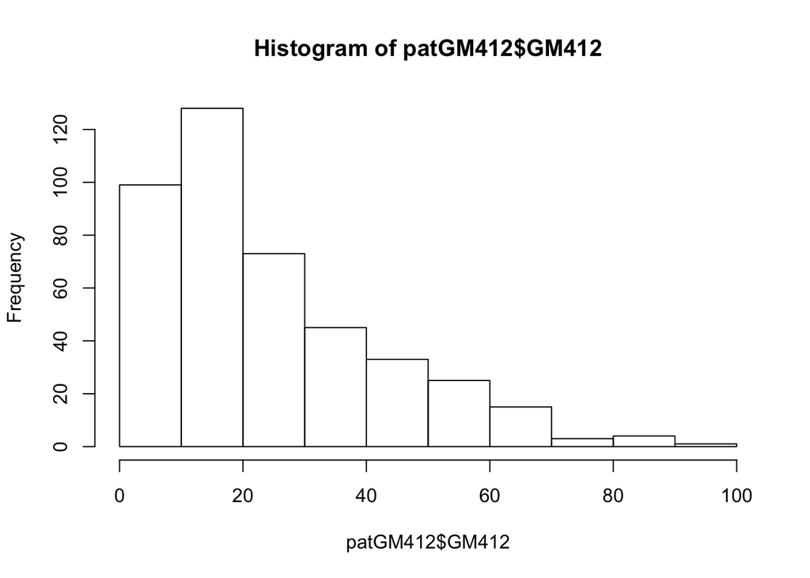

```r
fam <- read.table(my.dir %&% "genotypes/N88.forImputation.fam")
colnames(fam) <- c("FID","patno","father","mother","sex","pheno")
fam <- fam %>% mutate(IID=as.character(patno))
aud <- read.sas7bdat(pheno.dir %&% "audiometry.sas7bdat")
ageataudio <- read.sas7bdat(pheno.dir %&% "demographics.sas7bdat") %>% mutate(IID=as.character(patno))
finaldosing <- read.sas7bdat(pheno.dir %&% "finaldosing.sas7bdat") %>% mutate(IID=as.character(PATNO)) %>% dplyr::select(IID,CumlCispdose,CumlBLEOdose)
##divide by ear
airl<-filter(aud,C_AUDTEST==1,C_EARLR==1)
airr<-filter(aud,C_AUDTEST==1,C_EARLR==2)
###Pull db levels for 4-12 kHz
left <- airl %>% dplyr::select(C_CND4000, C_CND6000, C_CND8000, C_CND10000, C_CND12000)
right <- airr %>% dplyr::select(C_CND4000, C_CND6000, C_CND8000, C_CND10000, C_CND12000)
mean412 <- elementMean(list(left,right))
mean412<-replace(mean412,mean412<=1,1) ###set any db values <1 equal to 1, so can take the log
GM412 <- exp(rowMeans(log(mean412),na.rm=TRUE)) ##calc even if missing values
patGM412<- airl %>% dplyr::select(patno) %>% mutate(GM412=GM412,IID=as.character(patno))
patGM412 <- left_join(fam,patGM412,by="IID")
patageaudio <- left_join(fam,ageataudio,by="IID") %>% dplyr::select(FID,IID,ageaudio)
patcov <- left_join(patageaudio,finaldosing,by="IID")
hist(patGM412$GM412)
```

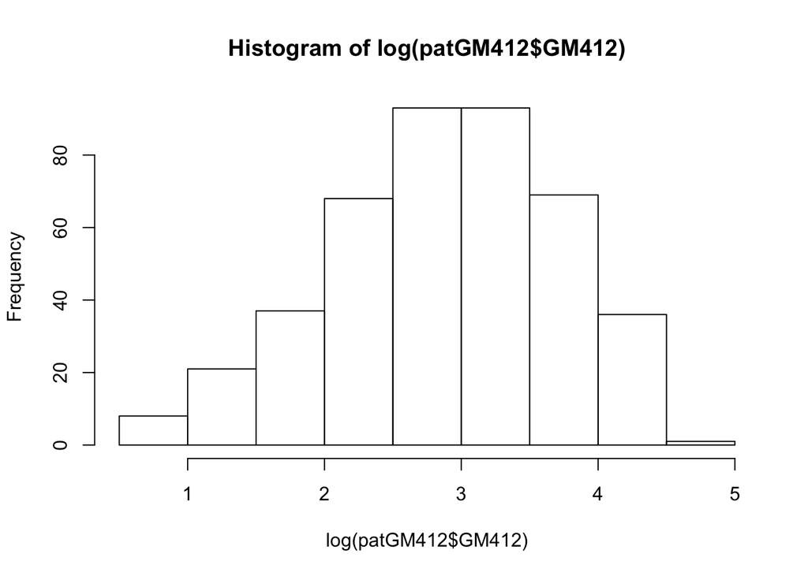

```r
hist(log(patGM412$GM412))
```

```r
shapiro.test(log(patGM412$GM412)) #rank-normalize?
```

```
##
##  Shapiro-Wilk normality test
##
## data:  log(patGM412$GM412)
## W = 0.98385, p-value = 0.0001098
```

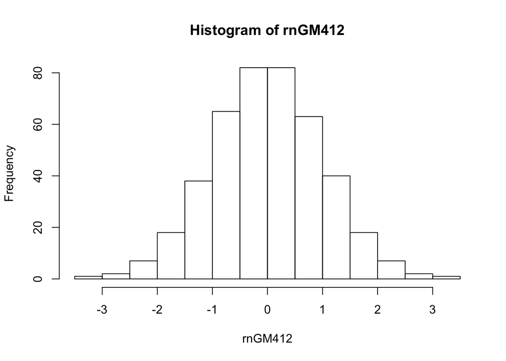

```r
rnGM412 <- rntransform(patGM412$GM412)
hist(rnGM412)
```

```r
patGM412 <- patGM412 %>% dplyr::select(FID,IID,GM412) %>% mutate(logGM412=log(GM412),rnGM412=rnGM412)

europcs <- read.table(my.dir %&% "genotypes/N88_euro_LDpruned_2015-11-18.evec",skip=1)
eupcdf <- europcs %>% rename(PC1=V2,PC2=V3,PC3=V4,PC4=V5,PC5=V6,PC6=V7,PC7=V8,PC8=V9,PC9=V10,PC10=V11)
patcov <- cbind(patcov,eupcdf[,2:11])

write.table(patGM412,file=my.dir %&% "genotypes/PtStudy.GM412.phenofile",quote=F,row.names = F,col.names = T)
write.table(patcov,file=my.dir %&% "genotypes/PtStudy.covfile",quote=F,row.names = F,col.names = T)

summary(lm(patGM412$rnGM412~patageaudio$ageaudio))$coef
```

```
##                         Estimate  Std. Error   t value     Pr(>|t|)
## (Intercept)          -2.46454321 0.166681155 -14.78597 3.425454e-40
## patageaudio$ageaudio  0.06207913 0.004081925  15.20830 5.365506e-42
```

```r
summary(lm(patGM412$rnGM412~patageaudio$ageaudio))$r.squared
```

```
## [1] 0.3529605
```

```r
#number nonmissing rnGM412 phenotypes (TRUE):
table(is.na(patGM412$rnGM412)==FALSE)
```

```
##
## FALSE  TRUE
##   527   426
```

```r
#number nonmissing ageaudio (TRUE):
table(is.na(patcov$ageaudio)==FALSE)
```

```
##
## FALSE  TRUE
##   527   426
```

```r
#number nonmissing CumlCispdose (TRUE):
table(is.na(patcov$CumlCispdose)==FALSE)
```

```
##
## FALSE  TRUE
##   531   422
```

```r
#pull Pt Study only
poppatGM412 <- patGM412 %>% mutate(pop=ifelse(grepl("TC",IID),"Norway","PtStudy"))
table(poppatGM412$pop)
```

```
##
##  Norway PtStudy
##     240     713
```

```r
PtpatGM412 <- poppatGM412 %>% dplyr::filter(pop=="PtStudy")
#number nonmissing rnGM412 phenotypes (TRUE):
table(is.na(PtpatGM412$rnGM412)==FALSE)
```

```
##
## FALSE  TRUE
##   287   426
```

```r
table(is.na(PtpatGM412$rnGM412)==FALSE)/sum(table(is.na(PtpatGM412$rnGM412)==FALSE))
```

```
##
##     FALSE      TRUE
## 0.4025245 0.5974755
```

### Divide sample into quartiles based on Engdahl

```r
###Pull db levels for 4-8 kHz
left <- airl %>% dplyr::select(C_CND4000, C_CND6000, C_CND8000)
right <- airr %>% dplyr::select(C_CND4000, C_CND6000, C_CND8000)
mean468 <- elementMean(list(left,right))
mean468<-replace(mean468,mean468<=1,1) ###set any db values <1 equal to 1, so can take the log
AUC468 <- exp(rowMeans(log(mean468)))
patData <- airl %>% dplyr::select(patno) %>% mutate(AUC_4_8kHz=AUC468)
a <- left_join(patData,ageataudio,by="patno")
patData <- a %>% dplyr::select(patno, ageaudio, AUC_4_8kHz)
###Define age groups per sample
group <- floor(patData$ageaudio) ##what I did previously, more pleasant graphic
for(i in 1:length(group)){
  if(is.na(group[i])){
    group[i] <- NA
  }
  else if(group[i] <= 29){
    group[i] <- 29
  }else if(group[i] > 29 && group[i] <= 39){
    group[i] <- 39
  }else if(group[i] > 39 && group[i] <= 49){
    group[i] <- 49
  }else if(group[i] > 49 && group[i] <= 59){
    group[i] <- 59
  }else if (group[i] > 59 && group[i] <= 69){
    group[i] <- 69
  }
}
patData <- patData %>% mutate(GROUP=group)
##4-8kHz normal AUCs calculated in Engdahl_def_quartiles.xlsx
engData <- read.table('~/GitHub/ThePlatinumStudy/Ototoxicity_modeling/Engdahl_quartile_AUCs_4-8kHz.txt',header=TRUE)
aucData <- left_join(patData,engData,by="GROUP")
aucData <- aucData[complete.cases(aucData),]

###calculate which quartile
quartile=aucData$AUC_4_8kHz
for(i in 1:dim(aucData)[1]){
  if(aucData$AUC_4_8kHz[i] < aucData$Q1[i]){
    quartile[i] <- 1
  }
  else if(aucData$AUC_4_8kHz[i] < aucData$Q2[i]){
    quartile[i] <- 2
  }
  else if(aucData$AUC_4_8kHz[i] < aucData$Q3[i]){
    quartile[i] <- 3
  }else{
    quartile[i] <- 4
  }
}

aucData <- mutate(aucData,QUARTILE=quartile,IID=as.character(patno))
phenCombo <- left_join(patGM412,aucData,by="IID")

table(aucData$QUARTILE)
```

```
##
##   1   2   3   4
## 104 168 121  94
```

```r
sum(table(aucData$QUARTILE))
```

```
## [1] 487
```

```r
table(aucData$QUARTILE)/sum(table(aucData$QUARTILE))
```

```
##
##         1         2         3         4
## 0.2135524 0.3449692 0.2484600 0.1930185
```

### Pull EORTC CIPN20: 8 sensory items (no hearing item)

```r
fam <- read.table(my.dir %&% "genotypes/N88.forImputation.fam")
colnames(fam) <- c("FID","patno","father","mother","sex","pheno")
fam <- fam %>% mutate(IID=as.character(patno))
demog <- read.sas7bdat(pheno.dir %&% "demographics.sas7bdat")
cipn8sens <- demog %>% dplyr::select(patno, agediagnosis, C_Q15ARSP, C_Q15BRSP, C_Q15CRSP, C_Q15DRSP, C_Q15ERSP, C_Q15FRSP, C_Q15IRSP, C_Q15JRSP) %>% rename(Tingling_hands=C_Q15ARSP, Tingling_feet=C_Q15BRSP, Numbness_hands=C_Q15CRSP, Numbness_feet=C_Q15DRSP, Shooting_pain_hands=C_Q15ERSP, Shooting_pain_feet=C_Q15FRSP, Problems_walking_feeling_ground=C_Q15IRSP, Difficulty_hot_cold_water=C_Q15JRSP)

##Calculate Cronbach's alpha
CIPN20_8sens <- cipn8sens[,3:10]
psych::alpha(CIPN20_8sens)$total
```

```
##  raw_alpha std.alpha   G6(smc) average_r      S/N        ase     mean
##  0.8795266 0.8840118 0.9018165 0.4878875 7.621568 0.01641028 0.386766
##         sd
##  0.5580039
```

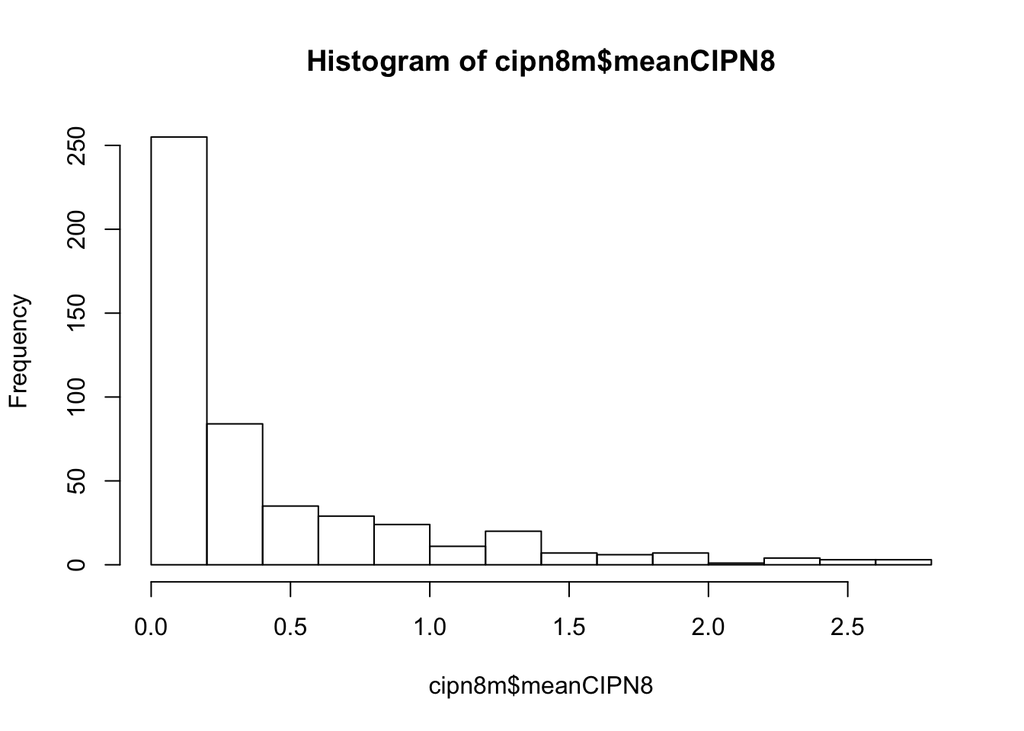

```r
cipn8m <- dplyr::select(cipn8sens,patno,agediagnosis) %>% mutate(IID=as.character(patno),meanCIPN8=rowMeans(CIPN20_8sens,na.rm=TRUE))
hist(cipn8m$meanCIPN8)
```

```r
table(cipn8m$meanCIPN8==0)
```

```
##
## FALSE  TRUE
##   281   208
```

```r
table(ceiling(cipn8m$meanCIPN8))
```

```
##
##   0   1   2   3
## 208 219  51  11
```

```r
table(ceiling(cipn8m$meanCIPN8))/sum(table(ceiling(cipn8m$meanCIPN8)))
```

```
##
##          0          1          2          3
## 0.42535787 0.44785276 0.10429448 0.02249489
```

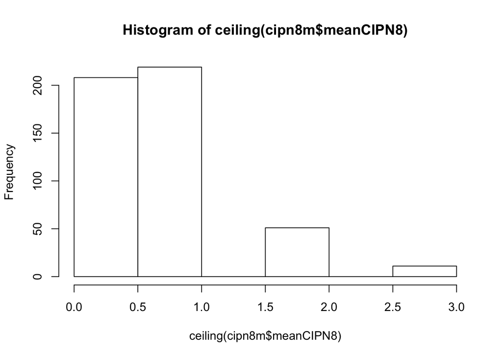

```r
hist(ceiling(cipn8m$meanCIPN8))
```

```r
##ordCIPN8 groups: meanCIPN8: 0, 0<x<=1, 1<x<=2, 2<x<=3
##biCIPN8: meanCIPN8=0, >0
##exCIPN8: meanCIPN8=0 vs 2or3
##ord3CIPN8 groups: meanCIPN8: 0, 0<x<=1, 1<x<=3
cipn8m <- dplyr::select(cipn8m,IID,agediagnosis,meanCIPN8) %>% mutate(ordCIPN8=ceiling(meanCIPN8),biCIPN8=ifelse(meanCIPN8==0,0,1)) %>% mutate(ord3CIPN8=ifelse(ordCIPN8==3,2,ordCIPN8))
exCIPN8 <- ifelse(cipn8m$ordCIPN8==1,NA,cipn8m$ordCIPN8)
exCIPN8 <- ifelse(exCIPN8>=2,1,exCIPN8)
cipn8m <- cipn8m %>% mutate(exCIPN8=exCIPN8)
table(cipn8m$exCIPN8)
```

```
##
##   0   1
## 208  62
```

```r
table(cipn8m$ord3CIPN8)
```

```
##
##   0   1   2
## 208 219  62
```

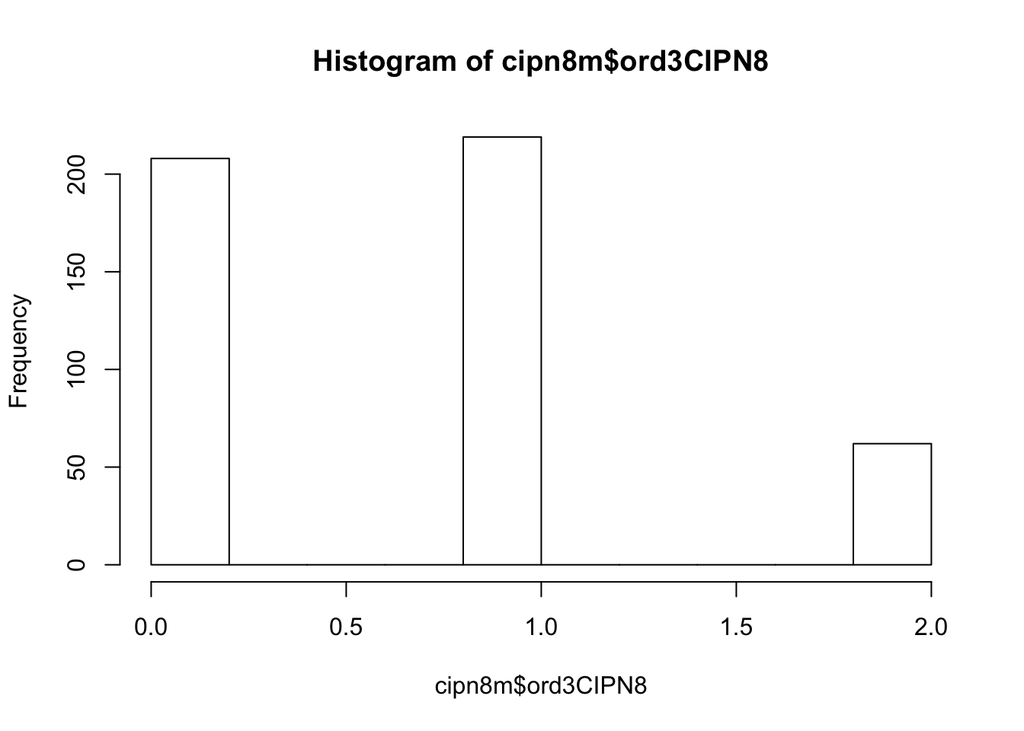

```r
hist(cipn8m$ord3CIPN8)
```

```r
head(cipn8m)
```

```
##     IID agediagnosis meanCIPN8 ordCIPN8 biCIPN8 ord3CIPN8 exCIPN8
## 1 30000         36.2     0.000        0       0         0       0
## 2 30001         24.0     0.000        0       0         0       0
## 3 30002         31.1     0.750        1       1         1      NA
## 4 30003         49.0     0.375        1       1         1      NA
## 5 30004         25.1     0.125        1       1         1      NA
## 6 30005         30.8     0.625        1       1         1      NA
```

```r
dim(cipn8m)
```

```
## [1] 494   7
```

```r
patcipn <- left_join(fam,cipn8m,by="IID") %>% dplyr::select(FID,IID,meanCIPN8,ordCIPN8,biCIPN8,exCIPN8,ord3CIPN8,agediagnosis)

write.table(patcipn,file=my.dir %&% "genotypes/PtStudy.CIPN8.phenofile",quote=F,row.names = F,col.names = T)


summary(lm(patcipn$agediagnosis~patcipn$ordCIPN8))$coef
```

```
##                  Estimate Std. Error   t value      Pr(>|t|)
## (Intercept)      30.46767  0.5508677 55.308507 6.222485e-195
## patcipn$ordCIPN8  2.73303  0.5489200  4.978922  9.351894e-07
```

```r
summary(lm(patcipn$agediagnosis~patcipn$ordCIPN8))$r.squared
```

```
## [1] 0.05573346
```

```r
#number nonmissing ordCIPN8 phenotypes (TRUE):
table(is.na(patcipn$ordCIPN8)==FALSE)
```

```
##
## FALSE  TRUE
##   531   422
```

```r
#number nonmissing exCIPN8 phenotypes (TRUE):
table(is.na(patcipn$exCIPN8)==FALSE)
```

```
##
## FALSE  TRUE
##   723   230
```

```r
phenCombo <- left_join(phenCombo,patcipn,by="IID")
phenCombo <- left_join(phenCombo,patcov,by="IID")
phenEric <- phenCombo %>% dplyr::select(FID.x, IID, GM412, rnGM412, logGM412, QUARTILE ,meanCIPN8,ordCIPN8,biCIPN8,ord3CIPN8,exCIPN8,ageaudio.x,agediagnosis,CumlCispdose,CumlBLEOdose) %>% dplyr::rename(FID=FID.x,quartile=QUARTILE,ageaudio=ageaudio.x)
phentable <- phenEric %>% mutate(CumlBLEOdose=ifelse(is.nan(CumlBLEOdose),NA,CumlBLEOdose)) #should any CumlBLEOdose == 0? Check before Raynaud's GWAS
```

test run:  
`plink --bfile N88.forImputation --1 --pheno PtStudy.CIPN8.phenofile --pheno-name biCIPN8 --logistic --adjust --covar PtStudy.covfile --out PtStudy.preImpute.2015-11-24.biCIPN8ageaudio.Cispdose`

`plink --bfile N88.forImputation --1 --pheno PtStudy.CIPN8.phenofile --pheno-name exCIPN8 --logistic --adjust --covar PtStudy.covfile --out PtStudy.preImpute.2015-11-24.exCIPN8ageaudio.Cispdose`

`plink --bfile N88.forImputation --1 --pheno PtStudy.CIPN8.phenofile --pheno-name biCIPN8 --logistic --adjust --covar PtStudy.covfile --covar-name ageaudio --out PtStudy.preImpute.2015-11-24.biCIPN8ageaudio`

`plink --bfile N88.forImputation --1 --pheno PtStudy.CIPN8.phenofile --pheno-name exCIPN8 --logistic --adjust --covar PtStudy.covfile --covar-name ageaudio --out PtStudy.preImpute.2015-11-24.exCIPN8ageaudio`

#### TO DO: code for ordinal regression phenotypes–>done, see 14_ordreg_GWAS.R

### Does ordCIPN8 associate with agediagnosis? CumlCispdose?

- only agediagnosis is signficant:

```r
phenofile <- ptcov.dir %&% "PtStudy.phenofile"
covfile <- ptcov.dir %&% "PtStudy.covfile"
pheno <- read.table(phenofile,header=T)
cov <- read.table(covfile,header=T) %>% dplyr::select(FID,starts_with("PC"))
pheno <- left_join(pheno,cov,by="FID")

#ordCIPN8 ~ agediagnosis
m<-polr(factor(pheno$ordCIPN8) ~ pheno$agediagnosis, Hess=TRUE)
p <- pnorm(abs(summary(m)$coefficients[, "t value"]), lower.tail = FALSE) * 2
or <- exp(summary(m)$coefficients[,"Value"])
ci <- exp(confint.default(m))
colnames(ci) <- c("lCI","uCI")
res <- cbind(summary(m)$coefficients[,],"OR"=or,"pval"=p)[1,]
res <- c(res, ci[1,])
res
```

```
##        Value   Std. Error      t value           OR         pval
## 6.077337e-02 1.171250e-02 5.188764e+00 1.062658e+00 2.116948e-07
##          lCI          uCI
## 1.038541e+00 1.087335e+00
```

```r
#ordCIPN8 ~ CumlCispdose
m<-polr(factor(pheno$ordCIPN8) ~ pheno$CumlCispdose, Hess=TRUE)
p <- pnorm(abs(summary(m)$coefficients[, "t value"]), lower.tail = FALSE) * 2
or <- exp(summary(m)$coefficients[,"Value"])
ci <- exp(confint.default(m))
colnames(ci) <- c("lCI","uCI")
res <- cbind(summary(m)$coefficients[,],"OR"=or,"pval"=p)[1,]
res <- c(res, ci[1,])
res
```

```
##         Value    Std. Error       t value            OR          pval
## -0.0005051741  0.0013156854 -0.3839627078  0.9994949534  0.7010060878
##           lCI           uCI
##  0.9969208801  1.0020756731
```

```r
#ordCIPN8 ~ agediagnosis + CumlCispdose
m<-polr(factor(pheno$ordCIPN8) ~ pheno$agediagnosis + pheno$CumlCispdose, Hess=TRUE)
p <- pnorm(abs(summary(m)$coefficients[, "t value"]), lower.tail = FALSE) * 2
or <- exp(summary(m)$coefficients[,"Value"])
ci <- exp(confint.default(m))
colnames(ci) <- c("lCI","uCI")
res <- cbind(summary(m)$coefficients[,],"OR"=or,"pval"=p)
res <- cbind(res[1:2,],ci)
res
```

```
##                            Value  Std. Error      t value        OR
## pheno$agediagnosis  6.195351e-02 0.011790189  5.254666084 1.0639129
## pheno$CumlCispdose -1.729781e-06 0.001328063 -0.001302484 0.9999983
##                            pval       lCI      uCI
## pheno$agediagnosis 1.482933e-07 1.0396095 1.088784
## pheno$CumlCispdose 9.989608e-01 0.9973987 1.002605
```

```r
#ordCIPN8 ~ agediagnosis + 10 PCs
covmat <- dplyr::select(pheno,agediagnosis,starts_with("PC"))
covmat <- as.matrix(covmat)
m<-polr(factor(pheno$ordCIPN8) ~ covmat, Hess=TRUE)
p <- pnorm(abs(summary(m)$coefficients[, "t value"]), lower.tail = FALSE) * 2
or <- exp(summary(m)$coefficients[,"Value"])
ci <- exp(confint.default(m))
colnames(ci) <- c("lCI","uCI")
res <- cbind(summary(m)$coefficients[,],"OR"=or,"pval"=p)
res <- cbind(res[1:dim(covmat)[2],], ci)
res
```

```
##                          Value Std. Error     t value          OR
## covmatagediagnosis  0.06307056  0.0118965  5.30160691   1.0651020
## covmatPC1           5.06428510  3.1147208  1.62591945 158.2672571
## covmatPC2          -0.13332562  2.9823869 -0.04470433   0.8751801
## covmatPC3          -1.52974025  3.0160564 -0.50719882   0.2165919
## covmatPC4          -0.21002865  2.9875912 -0.07030033   0.8105610
## covmatPC5           3.31863233  2.8402890  1.16841361  27.6225463
## covmatPC6          -1.72106017  2.8123056 -0.61197481   0.1788764
## covmatPC7           2.54913441  3.0645958  0.83180118  12.7960229
## covmatPC8           0.13225270  3.0394968  0.04351138   1.1413967
## covmatPC9          -0.83791372  2.9612664 -0.28295790   0.4326121
## covmatPC10          0.35171061  2.9112114  0.12081246   1.4214971
##                            pval          lCI          uCI
## covmatagediagnosis 1.147878e-07 1.0405546089     1.090228
## covmatPC1          1.039668e-01 0.3532937402 70899.995710
## covmatPC2          9.643430e-01 0.0025321249   302.489088
## covmatPC3          6.120153e-01 0.0005866383    79.967605
## covmatPC4          9.439546e-01 0.0023213652   283.027063
## covmatPC5          2.426400e-01 0.1055857544  7226.401591
## covmatPC6          5.405544e-01 0.0007222944    44.298794
## covmatPC7          4.055212e-01 0.0315127506  5195.934901
## covmatPC8          9.652939e-01 0.0029526519   441.225890
## covmatPC9          7.772091e-01 0.0013045604   143.460786
## covmatPC10         9.038396e-01 0.0047284449   427.340076
```

```r
#ordCIPN8 ~ agediagnosis + CumlCispdose + 10 PCs
covmat <- dplyr::select(pheno,agediagnosis,CumlCispdose,starts_with("PC"))
covmat <- as.matrix(covmat)
m<-polr(factor(pheno$ordCIPN8) ~ covmat, Hess=TRUE)
p <- pnorm(abs(summary(m)$coefficients[, "t value"]), lower.tail = FALSE) * 2
or <- exp(summary(m)$coefficients[,"Value"])
ci <- exp(confint.default(m))
colnames(ci) <- c("lCI","uCI")
res <- cbind(summary(m)$coefficients[,],"OR"=or,"pval"=p)
res <- cbind(res[1:dim(covmat)[2],], ci)
res
```

```
##                            Value   Std. Error       t value          OR
## covmatagediagnosis  6.370760e-02 0.0118563610  5.373285e+00   1.0657807
## covmatCumlCispdose -4.922505e-05 0.0013304125 -3.699984e-02   0.9999508
## covmatPC1           4.773722e+00 0.0096391827  4.952413e+02 118.3589248
## covmatPC2          -2.741714e-01 0.0022315459 -1.228616e+02   0.7602018
## covmatPC3          -1.182246e+00 0.0045608920 -2.592138e+02   0.3065893
## covmatPC4           9.525678e-02 0.0108606197  8.770842e+00   1.0999413
## covmatPC5           2.988216e+00 0.0071981029  4.151394e+02  19.8502406
## covmatPC6          -1.194455e+00 0.0086581252 -1.379577e+02   0.3028689
## covmatPC7           2.053711e+00 0.0001256252  1.634791e+04   7.7967785
## covmatPC8           2.213692e-03 0.0027441130  8.067058e-01   1.0022161
## covmatPC9          -1.055962e+00 0.0033655541 -3.137558e+02   0.3478576
## covmatPC10          6.905618e-01 0.0050008158  1.380898e+02   1.9948359
##                            pval         lCI         uCI
## covmatagediagnosis 7.731509e-08   1.0412996   1.0908374
## covmatCumlCispdose 9.704851e-01   0.9973467   1.0025616
## covmatPC1          0.000000e+00 116.1438248 120.6162712
## covmatPC2          0.000000e+00   0.7568841   0.7635340
## covmatPC3          0.000000e+00   0.3038608   0.3093422
## covmatPC4          1.773353e-18   1.0767749   1.1236061
## covmatPC5          0.000000e+00  19.5721591  20.1322730
## covmatPC6          0.000000e+00   0.2977727   0.3080523
## covmatPC7          0.000000e+00   7.7948591   7.7986985
## covmatPC8          4.198360e-01   0.9968403   1.0076209
## covmatPC9          0.000000e+00   0.3455706   0.3501598
## covmatPC10         0.000000e+00   1.9753792   2.0144842
```

### Pull SCIN

- Tinnitus: ordTin (C_Q27ERSP)
- Reduced Hearing: ordHL (C_Q27FRSP)
- Raynaud’s: ordRay (mean C_Q27CRSP & C_Q27DRSP, take ceiling)
- also pull CumlBLEOdose
- add to PtStudy.phenofile

```r
fam <- read.table(my.dir %&% "genotypes/N88.forImputation.fam")
colnames(fam) <- c("FID","patno","father","mother","sex","pheno")
fam <- fam %>% mutate(IID=as.character(patno))
demog <- read.sas7bdat(pheno.dir %&% "demographics.sas7bdat")
scin <- demog %>% dplyr::select(patno,C_Q27ARSP,C_Q27BRSP,C_Q27CRSP,C_Q27DRSP,C_Q27ERSP,C_Q27FRSP) %>% rename(Pain_Tingling_Feet=C_Q27ARSP,Pain_Tingling_Hands=C_Q27BRSP,White_Cold_Hands=C_Q27CRSP,White_Cold_Feet=C_Q27DRSP,ordTin=C_Q27ERSP,ordHL=C_Q27FRSP)
a<-scin
dim(a)
```

```
## [1] 494   7
```

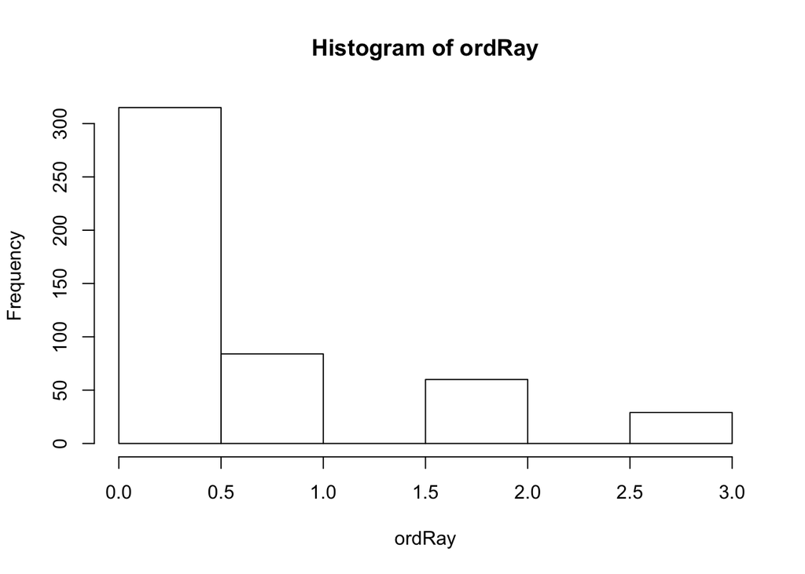

```r
ray <- dplyr::select(scin,White_Cold_Hands,White_Cold_Feet)
ordRay <- ceiling(rowMeans(ray,na.rm=TRUE))
hist(ordRay)
```

```r
table(ordRay)/sum(table(ordRay))
```

```
## ordRay
##          0          1          2          3
## 0.64549180 0.17213115 0.12295082 0.05942623
```

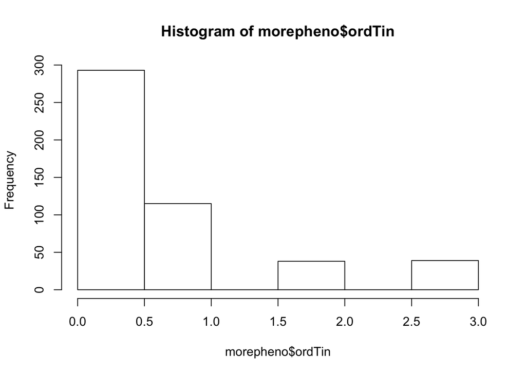

```r
morepheno <- dplyr::select(scin,patno,ordTin,ordHL) %>% mutate(IID=as.character(patno),ordRay=ordRay)
hist(morepheno$ordTin)
```

```r
table(morepheno$ordTin)/sum(table(morepheno$ordTin))
```

```
##
##          0          1          2          3
## 0.60412371 0.23711340 0.07835052 0.08041237
```

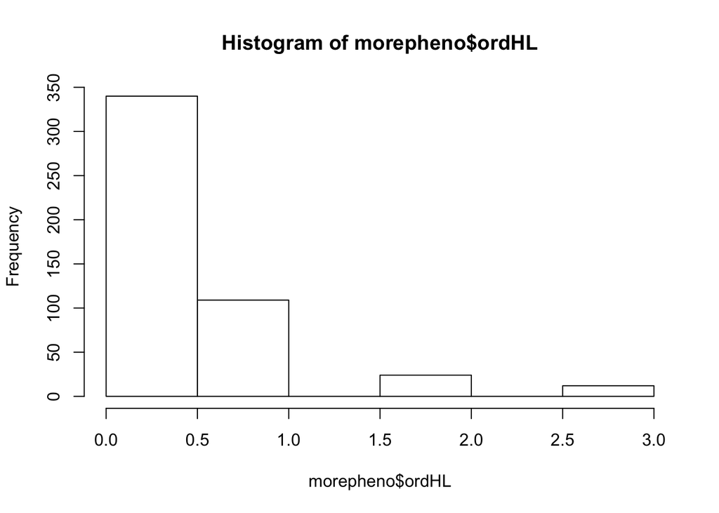

```r
hist(morepheno$ordHL)
```

```r
table(morepheno$ordHL)/sum(table(morepheno$ordHL))
```

```
##
##          0          1          2          3
## 0.70103093 0.22474227 0.04948454 0.02474227
```

```r
phentable2<-left_join(phentable,morepheno,by="IID")
write.table(phentable2,file=my.dir %&% "genotypes/PtStudy.phenofile",quote=F,row.names = F,col.names = T)
```